# R Notebook

2 MVP

Question 1.

Load in the libraries you need, and look at the backpack data. Take note of variable names and dimensions.

```r
colnames(backpack)
```

```
[1] "backpack_weight" "body_weight"     "ratio"           "back_problems"   "major"
[6] "year"            "sex"             "status"          "units"
```

```r
dim(backpack)
```

```
[1] 100   9
```

Question 2.

What is the distribution of backpack weights that students are carrying? Choose an appropriate graph to show the distribution.

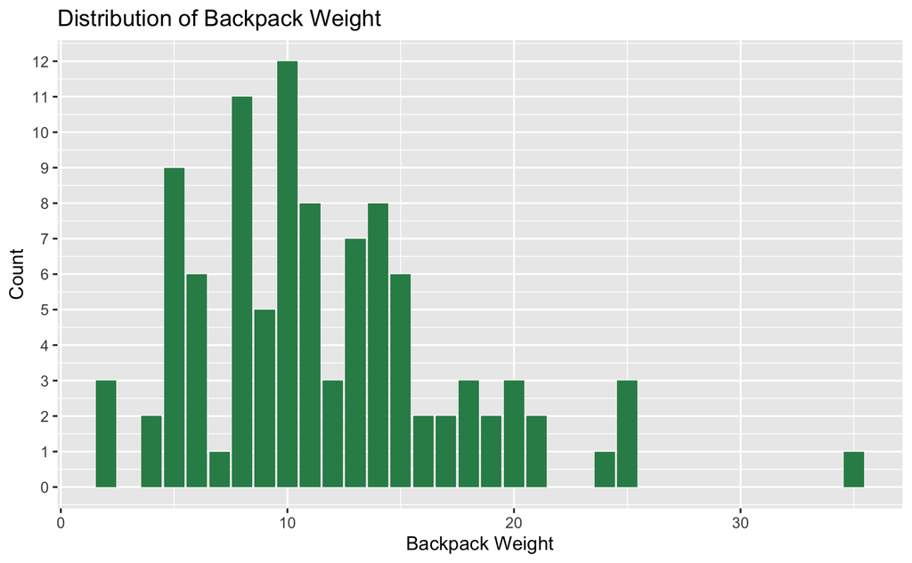

```r
ggplot(backpack)+
  aes(x = backpack_weight)+
  geom_bar(fill = "seagreen")+
  labs(x = "Backpack Weight",
       y = "Count",
       title = "Distribution of Backpack Weight")+
  scale_y_continuous(breaks = (0:12))
```

Question 3.

Are there differences in backpack weight between sex?

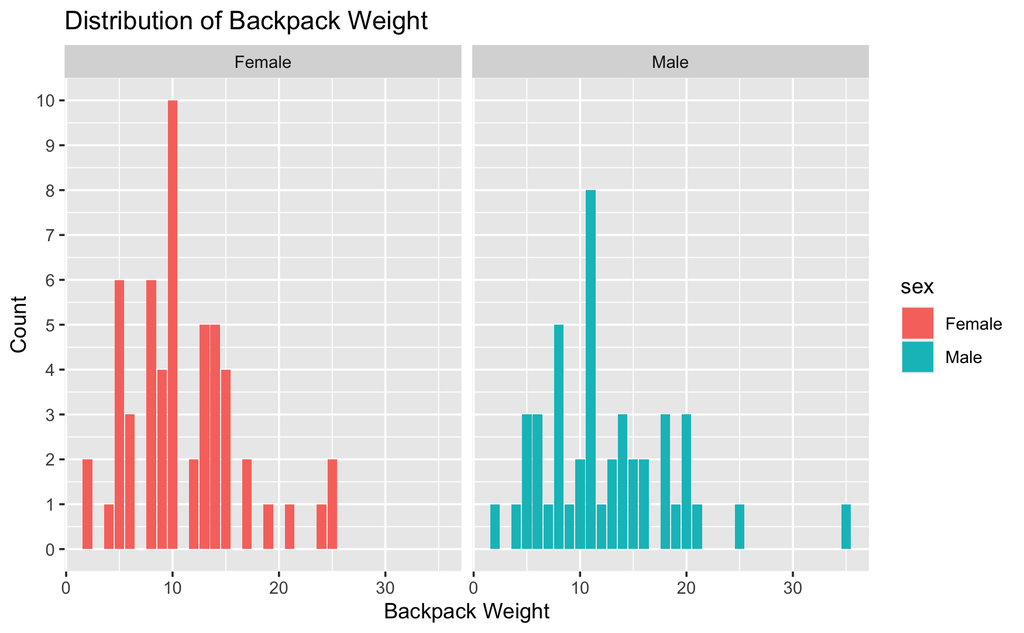

```r
ggplot(backpack)+
  aes(x = backpack_weight)+
  geom_bar(aes(fill = sex))+
  facet_grid(~sex)+
  labs(x = "Backpack Weight",
       y = "Count",
       title = "Distribution of Backpack Weight")+
  scale_y_continuous(breaks = (0:12))
```

Question 4.

What is the relationship between body weight and backpack weight?

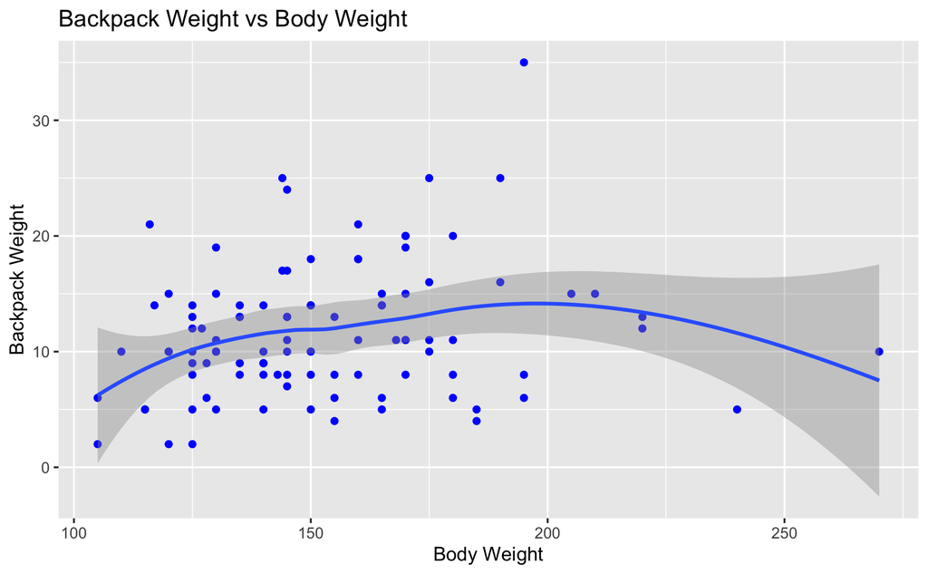

```r
ggplot(backpack)+
  aes(x = body_weight, y = backpack_weight)+
  geom_point(colour = "blue")+
  geom_smooth()+
  labs(y = "Backpack Weight",
       x = "Body Weight",
       title = "Backpack Weight vs Body Weight")
```

```r
NA
```

Question 5.

Is this relationship different between men and women? Choose an appropriate plot and interpret your findings.

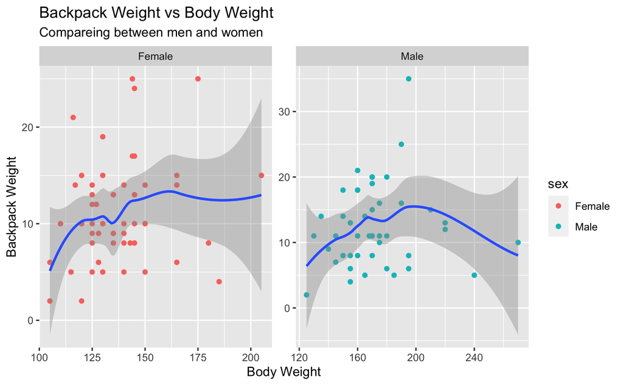

```r
ggplot(backpack)+
  aes(x = body_weight, y = backpack_weight)+
  geom_point(aes(colour = sex))+
  facet_wrap(~sex, scales ="free")+
  geom_smooth()+
  labs(y = "Backpack Weight",
       x = "Body Weight",
       title = "Backpack Weight vs Body Weight",
       subtitle = "Compareing between men and women")
```

Question 6.

What proportion of students report back pain?

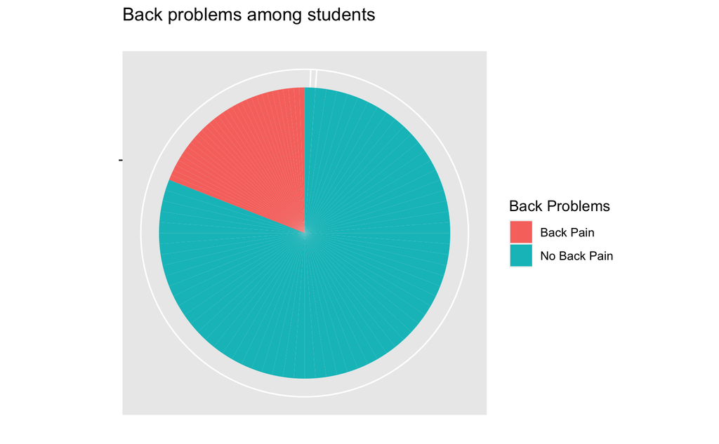

```r
backpack_p <- backpack %>%
  mutate(back_problems = ifelse(back_problems == 1,"Back Pain", "No Back Pain"))

ggplot(backpack_p)+
  aes(y = back_problems, x = "",fill = back_problems)+
  geom_bar(width = 1, stat = "identity")+
  coord_polar("y", start = 0) +
  theme(axis.ticks.x = element_blank(),
        axis.text.x = element_blank())+
  labs(x = "",
       y = "",
       title = "Back problems among students\n",
       fill = "Back Problems")
```

```r
NA
NA
```

Question 7.

Is this proportion different between men and women?

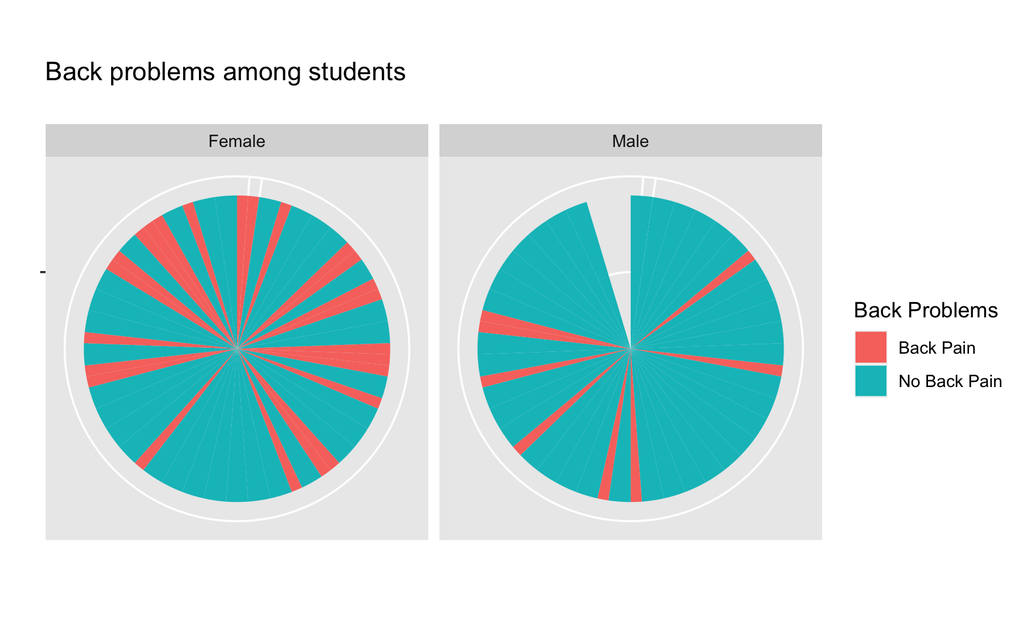

```r
ggplot(backpack_p)+
  aes(y = back_problems, x= "", group = sex, fill = as_factor(back_problems))+
  geom_bar(width = 1, stat = "identity") +
  coord_polar("y", start=0) +
  facet_grid(~ sex)+
  theme(axis.ticks.x = element_blank(),
        axis.text.x = element_blank())+
  labs(x = "",
       y = "",
       title = "Back problems among students\n",
       fill = "Back Problems")
```

```r
#
```

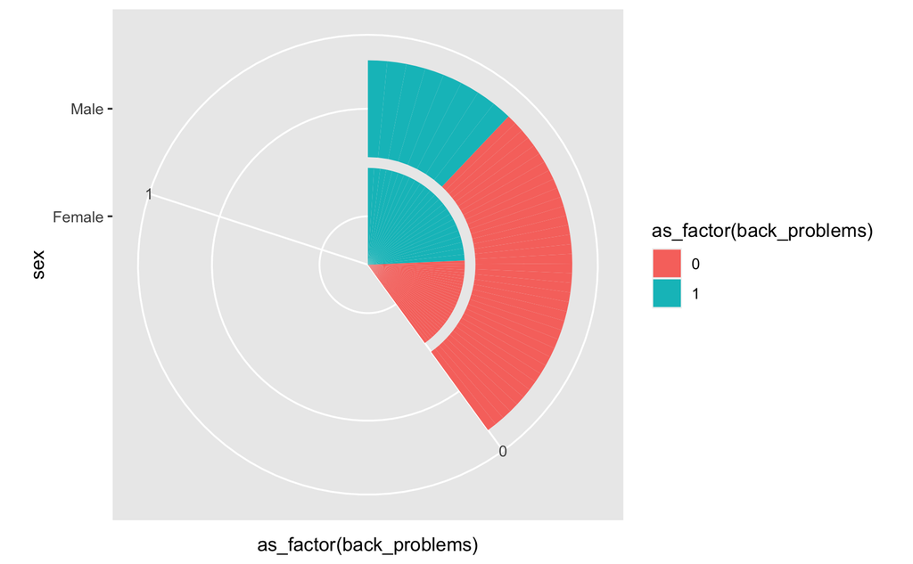

```r
ggplot(backpack, aes(x = sex, y = as_factor(back_problems), fill = as_factor(back_problems))) +
  geom_col(position = "fill")  +coord_polar("y")
```

Question 8.

Now you’ve investigated your data separately, create plots to describe the relationship between backpack weight, body weight, gender and reported backpain.

Try both backpack_weight and body_weight as well as the ratio.

Hint: faceting would be useful here.

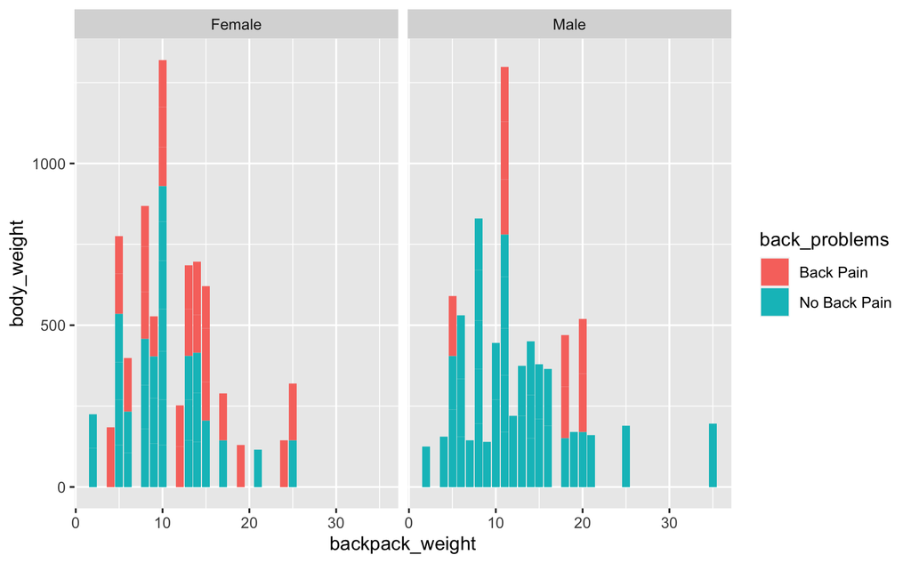

```r
ggplot(backpack_p)+
  aes(x=backpack_weight, y=body_weight)+
  geom_col(aes(fill = back_problems))+
  facet_grid(~sex)
```

3 Extensions

Question 1.

Does reported backpain differ across the year groups? Ignore year 0 in your data.

Question 2.

Is there a difference between how heavy the bags those in different years carry?